# Outside Item Memory

> This notebook focuses on item memory outside the rooms.

# 1 Overview of the data

The rooms were separated into *Familiar* and *Novel* groups. Participants explored the *Familiar* group at the beginning of the experiment. In the encoding task, they visisted both *Familiar* and *Novel* groups. Their item memory (i.e., in which room they saw the item) was tested in the memory test the next day of the encoding task. **Novelty benefits** on the item memory are examined by comparing the memory performance between the *Familiar* and *Novel* groups.

Participants were also asked to rate how curious they felt about the room. The higher the rating is means they felt more curious about the room. Item memory as a function of curiosity rating was also examined for **curiosity benefits**.

Questionnaires on personal traits regarding curiosity were also administered to participants before the encoding task (i.e., PC and EC). Scores on these questionnaires might be able to predict the item memory or its relationship with curiosity rating.

In the encoding task, there were 6 objects in each room. It is possbile that the item memory for the object to some extent depends on the order in which the object was seen. For example, it may be easier to remember where the first and last objects were seen as compared to those in the middle.

# 2 Visual inspection of the data

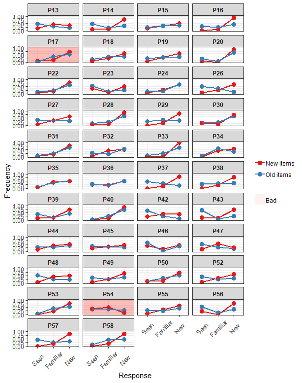

# 3 Novelty Benefits

We hypothesised that the memory for the items outside the rooms should be better for the *novel* rooms than for the *familiar* rooms.

## 3.1 Compare mean accuracy between *novel* and *familiar* rooms

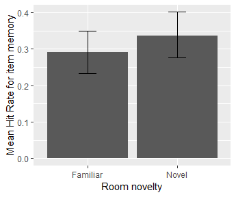

## 3.2 Item memory as a function of item order

### 3.2.2 Testing novelty effects by fitting mixed models

Build models with item memory accuracy as $y$ and then examine effects of novelty by comparing the models.

- `baseline.item` is the model with only an intercept.
- `order.model.linear.1` is the model with $\small ItemOrder$ included, showing the effects of item order.
- `order.model.linear.2` is the model allowing the slope (i.e., relationship between item memory and item order) varying across participants.
- `order.model.quad.1` and `order.model.quad.2` repectively included $\small ItemOrder^2$ and related random effects.
- `novelty.model.1` is the model with $\small Group$ (i.e., *familiar* and *novel* rooms) included, examining the effects of novelty of the rooms on the intercept (i.e., mean item memory accuracy at the 1st order or overall if no difference in slope).
- `novelty.model.2` is the model with interaction between $\small Group$ and $\small ItemOrder$ included, examining the effects of novelty on how item memory accuracy changes as a function of item order.
- `novelty.model.3` included interaction between $\small Group$ and $\small ItemOrder^2$ for inestigating whether the pattern changes between *familiar* and *novel* groups.

|  | Model | df | AIC | BIC | logLik | Test | L.Ratio | p-value |
| --- | --- | --- | --- | --- | --- | --- | --- | --- |
| baseline.item | 1 | 4 | 1746.485 | 1767.507 | -869.2424 |  |  |  |
| order.model.linear.1 | 2 | 5 | 1740.973 | 1767.251 | -865.4867 | 1 vs 2 | 7.511521 | 0.0061 |
| order.model.quad.1 | 3 | 6 | 1739.842 | 1771.376 | -863.9210 | 2 vs 3 | 3.131334 | 0.0768 |
| novelty.model.1 | 4 | 7 | 1739.024 | 1775.813 | -862.5118 | 3 vs 4 | 2.818394 | 0.0932 |
| novelty.model.2 | 5 | 8 | 1739.116 | 1781.161 | -861.5580 | 4 vs 5 | 1.907679 | 0.1672 |
| novelty.model.3 | 6 | 9 | 1741.009 | 1788.309 | -861.5043 | 5 vs 6 | 0.107331 | 0.7432 |

#### 3.2.2.1 Parameter estimation for the complete model

```
Linear mixed-effects model fit by maximum likelihood
 Data: Curiosity.Recall.Old[!SubjectNo %in% bad.ps.less.strict]
```

|  | AIC | BIC | logLik |
| --- | --- | --- | --- |
|  | 1741.009 | 1788.309 | -861.5043 |

```
Random effects:
 Formula: ~1 | SubjectNo
        (Intercept)
StdDev:   0.1597193

 Formula: ~1 | Group %in% SubjectNo
        (Intercept)  Residual
StdDev: 0.009745695 0.4336663

Fixed effects: SeenHit ~ ItemOrder + I(ItemOrder^2) + Group + ItemOrder:Group +      I(ItemOrder^2):Group
```

|  | Value | Std.Error | DF | t-value | p-value |
| --- | --- | --- | --- | --- | --- |
| (Intercept) | 0.3875572 | 0.07593078 | 1332 | 5.104085 | 0.0000 |
| ItemOrder | -0.0558111 | 0.04682097 | 1332 | -1.192012 | 0.2335 |
| I(ItemOrder^2) | 0.0066586 | 0.00654769 | 1332 | 1.016938 | 0.3094 |
| GroupNovel | 0.1372964 | 0.10123446 | 39 | 1.356222 | 0.1828 |
| ItemOrder:GroupNovel | -0.0398305 | 0.06621485 | 1332 | -0.601534 | 0.5476 |
| I(ItemOrder^2):GroupNovel | 0.0030266 | 0.00925984 | 1332 | 0.326856 | 0.7438 |

```
 Correlation:
                          (Intr) ItmOrd I(ItO^2) GrpNvl ItO:GN
ItemOrder                 -0.878
I(ItemOrder^2)             0.805 -0.979
GroupNovel                -0.667  0.658 -0.604
ItemOrder:GroupNovel       0.621 -0.707  0.692   -0.931
I(ItemOrder^2):GroupNovel -0.569  0.692 -0.707    0.854 -0.979

Standardized Within-Group Residuals:
       Min         Q1        Med         Q3        Max
-1.6309416 -0.7303324 -0.3594163  1.0909720  2.1572953

Number of Observations: 1416
Number of Groups:
           SubjectNo Group %in% SubjectNo
                  40                   80
```

#### 3.2.2.2 Parameter estimation for the optimal model

```
Linear mixed-effects model fit by maximum likelihood
 Data: Curiosity.Recall.Old[!SubjectNo %in% bad.ps.less.strict]
```

|  | AIC | BIC | logLik |
| --- | --- | --- | --- |
|  | 1739.024 | 1775.813 | -862.5118 |

```
Random effects:
 Formula: ~1 | SubjectNo
        (Intercept)
StdDev:   0.1597088

 Formula: ~1 | Group %in% SubjectNo
        (Intercept) Residual
StdDev: 0.009677789 0.433984

Fixed effects: SeenHit ~ ItemOrder + I(ItemOrder^2) + Group
```

|  | Value | Std.Error | DF | t-value | p-value |
| --- | --- | --- | --- | --- | --- |
| (Intercept) | 0.4343089 | 0.05776727 | 1334 | 7.518252 | 0.0000 |
| ItemOrder | -0.0757264 | 0.03310821 | 1334 | -2.287239 | 0.0223 |
| I(ItemOrder^2) | 0.0081719 | 0.00463003 | 1334 | 1.764981 | 0.0778 |
| GroupNovel | 0.0437935 | 0.02320062 | 39 | 1.887599 | 0.0665 |

```
 Correlation:
               (Intr) ItmOrd I(IO^2
ItemOrder      -0.816
I(ItemOrder^2)  0.748 -0.979
GroupNovel     -0.201  0.000  0.000

Standardized Within-Group Residuals:
       Min         Q1        Med         Q3        Max
-1.5693761 -0.7209143 -0.3692786  1.0848881  2.1673927

Number of Observations: 1416
Number of Groups:
           SubjectNo Group %in% SubjectNo
                  40                   80
```

#### 3.2.3.1 Stats on it

```
Linear mixed-effects model fit by maximum likelihood
 Data: Curiosity.Recall.Old.Collapsed.Grp[!SubjectNo %in% bad.ps.less.strict]
```

|  | AIC | BIC | logLik |
| --- | --- | --- | --- |
|  | -74.30176 | -49.70036 | 45.15088 |

```
Random effects:
 Formula: ~1 | SubjectNo
        (Intercept)
StdDev:   0.1582867

 Formula: ~1 | Group %in% SubjectNo
        (Intercept)
StdDev:  0.03855752

 Formula: ~1 | ItemOrderType %in% Group %in% SubjectNo
        (Intercept)   Residual
StdDev:   0.1366038 0.04347128

Fixed effects: SeenHit ~ Group * ItemOrderType
```

|  | Value | Std.Error | DF | t-value | p-value |
| --- | --- | --- | --- | --- | --- |
| (Intercept) | 0.29861111 | 0.03474882 | 78 | 8.593418 | 0.0000 |
| GroupNovel | 0.07222222 | 0.03361703 | 39 | 2.148382 | 0.0380 |
| ItemOrderTypeLate | -0.01250000 | 0.03246328 | 78 | -0.385050 | 0.7012 |
| GroupNovel:ItemOrderTypeLate | -0.05416667 | 0.04591001 | 78 | -1.179844 | 0.2416 |

```
 Correlation:
                             (Intr) GrpNvl ItmOTL
GroupNovel                   -0.484
ItemOrderTypeLate            -0.467  0.483
GroupNovel:ItemOrderTypeLate  0.330 -0.683 -0.707

Standardized Within-Group Residuals:
       Min         Q1        Med         Q3        Max
-0.5359479 -0.1775494 -0.0170921  0.1770284  0.6477224

Number of Observations: 160
Number of Groups:
                              SubjectNo                    Group %in% SubjectNo
                                     40                                      80
ItemOrderType %in% Group %in% SubjectNo
                                    160
```

##### 3.2.3.1.1 Simple effects for the “early” group

```
    Paired t-test

data:  SeenHit by Group
t = -2.3475, df = 39, p-value = 0.02407
alternative hypothesis: true difference in means is not equal to 0
95 percent confidence interval:
 -0.134450862 -0.009993583
sample estimates:
mean of the differences
            -0.07222222
```

##### 3.2.3.1.2 Simple effects for the “late” group

```
    Paired t-test

data:  SeenHit by Group
t = -0.56687, df = 39, p-value = 0.5741
alternative hypothesis: true difference in means is not equal to 0
95 percent confidence interval:
 -0.08248111  0.04637000
sample estimates:
mean of the differences
            -0.01805556
```

# 4 Curiosity Benefits

We hypothesed that the higher the curiosity rating was, the better the item memory should be.

## 4.1 Mean accuracy of item memory as a function of curiosity rating

### 4.1.1 Testing the relationship between mean accuracy of item memory and curiosity rating

Build models with item memory accuracy as $y$ and examine effects of curiosity rating by including it into the model and then comparing the model fits.

- `baseline.rating` is the model with only an intercept, showing no change in item memory as a function of curiosity rating.
- `rating.intercept` is the model with $\small CuriosityRating$ included, showing the effects of curiosity rating.
- `rating.slope` is the model allowing the slope (i.e., relationship between item memory and curiosity rating) varying across participants.

|  | Model | df | AIC | BIC | logLik | Test | L.Ratio | p-value |
| --- | --- | --- | --- | --- | --- | --- | --- | --- |
| baseline.rating | 1 | 3 | -58.01060 | -47.61910 | 32.00530 |  |  |  |
| rating.intercept | 2 | 4 | -62.28458 | -48.42925 | 35.14229 | 1 vs 2 | 6.273985 | 0.0123 |
| rating.slope | 3 | 6 | -62.57440 | -41.79141 | 37.28720 | 2 vs 3 | 4.289821 | 0.1171 |

#### 4.1.1.1 Parameter estimates in the complete model

```r
summary(rating.slope)
```

```
Linear mixed-effects model fit by maximum likelihood
 Data: OutsideObjectsMemory[!SubjectNo %in% bad.ps.less.strict]
```

|  | AIC | BIC | logLik |
| --- | --- | --- | --- |
|  | -62.5744 | -41.79141 | 37.2872 |

```
Random effects:
 Formula: ~1 + CuriosityRating | SubjectNo
 Structure: General positive-definite, Log-Cholesky parametrization
                StdDev     Corr
(Intercept)     0.19505328 (Intr)
CuriosityRating 0.03095239 -0.612
Residual        0.17089421

Fixed effects: SeenHit ~ CuriosityRating
```

|  | Value | Std.Error | DF | t-value | p-value |
| --- | --- | --- | --- | --- | --- |
| (Intercept) | 0.23380955 | 0.04372823 | 195 | 5.346878 | 0.000 |
| CuriosityRating | 0.01722689 | 0.00806864 | 195 | 2.135043 | 0.034 |

```
 Correlation:
                (Intr)
CuriosityRating -0.783

Standardized Within-Group Residuals:
        Min          Q1         Med          Q3         Max
-2.15186988 -0.60206411 -0.06669062  0.54361482  2.58062728

Number of Observations: 236
Number of Groups: 40
```

## 4.2 Does the relationship with curiosity rating depend on item order?

### 4.2.1 Testing the effect of item order

Build models with context memory accuracy as $y$ and examine effects of curiosity rating and item order by comparing the models.

- `item.model.linear.1` is the model with $\small ItemOrder$ included (in addition to $\small CuriosityRating$), showing the effects of item order.
- `item.model.linear.2` is the model allowing the slope (i.e., relationship between item memory and item order) varying across participants.
- `item.model.linear.3` is the model with the interaction between $\small ItemOrders$ and $\small CuriosityRating$ included.
- `item.model.quad.1` and `item.model.quad.2` repectively included $\small ItemOrder^2$ and related random effects.
- `item.model.quad.3` included interaction between $\small ItemOrder^2$ and $\small CuriosityRating$ for inestigating whether the pattern changes as a function of *curiosity rating*.

```r
rating.intercept <- update(baseline.item, .~. + CuriosityRating)
rating.slope     <- update(rating.intercept, random = ~ 1 + CuriosityRating | SubjectNo)
item.model.linear.1     <- update(rating.slope, .~. + ItemOrder)
item.model.linear.2     <- update(item.model.linear.1, random = ~1+CuriosityRating + ItemOrder|SubjectNo)
item.model.linear.3     <- update(item.model.linear.2, .~. + ItemOrder : CuriosityRating)
item.model.quad.1       <- update(item.model.linear.3, .~. + I(ItemOrder^2))
item.model.quad.2       <- update(item.model.quad.1,   random = ~1+CuriosityRating+ItemOrder+I(ItemOrder^2)|SubjectNo) # excluding this model because singularity issue (perhaps the model was getting too complex to be calculated)
item.model.quad.3       <- update(item.model.quad.2,   .~. + I(ItemOrder^2) : CuriosityRating)
anova(baseline.item, rating.intercept, rating.slope, item.model.linear.1, item.model.linear.2, item.model.linear.3, item.model.quad.1, item.model.quad.2, item.model.quad.3)
```

|  | Model | df | AIC | BIC | logLik | Test | L.Ratio | p-value |
| --- | --- | --- | --- | --- | --- | --- | --- | --- |
| baseline.item | 1 | 4 | 1746.485 | 1767.507 | -869.2424 |  |  |  |
| rating.intercept | 2 | 5 | 1742.708 | 1768.986 | -866.3538 | 1 vs 2 | 5.777305 | 0.0162 |
| rating.slope | 3 | 6 | 1740.706 | 1772.239 | -864.3528 | 2 vs 3 | 4.001939 | 0.0454 |
| item.model.linear.1 | 4 | 7 | 1735.105 | 1771.894 | -860.5524 | 3 vs 4 | 7.600926 | 0.0058 |
| item.model.linear.2 | 5 | 10 | 1734.072 | 1786.628 | -857.0358 | 4 vs 5 | 7.033044 | 0.0709 |
| item.model.linear.3 | 6 | 11 | 1736.067 | 1793.879 | -857.0335 | 5 vs 6 | 0.004680 | 0.9455 |
| item.model.quad.1 | 7 | 12 | 1734.848 | 1797.915 | -855.4240 | 6 vs 7 | 3.218971 | 0.0728 |
| item.model.quad.2 | 8 | 16 | 1740.100 | 1824.189 | -854.0500 | 7 vs 8 | 2.748075 | 0.6008 |
| item.model.quad.3 | 9 | 17 | 1741.723 | 1831.068 | -853.8614 | 8 vs 9 | 0.377167 | 0.5391 |

#### 4.2.1.1 Parameter estimation for the optimal model

```r
summary(item.model.linear.2 )
```

```
Linear mixed-effects model fit by maximum likelihood
 Data: Curiosity.Recall.Old[!SubjectNo %in% bad.ps.less.strict]
```

|  | AIC | BIC | logLik |
| --- | --- | --- | --- |
|  | 1734.072 | 1786.628 | -857.0358 |

```
Random effects:
 Formula: ~1 + CuriosityRating + ItemOrder | SubjectNo
 Structure: General positive-definite, Log-Cholesky parametrization
                StdDev     Corr
(Intercept)     0.24378985 (Intr) CrstyR
CuriosityRating 0.02957138 -0.395
ItemOrder       0.03109774 -0.649 -0.173
Residual        0.42774805

Fixed effects: SeenHit ~ CuriosityRating + ItemOrder
```

|  | Value | Std.Error | DF | t-value | p-value |
| --- | --- | --- | --- | --- | --- |
| (Intercept) | 0.29790202 | 0.05489907 | 1374 | 5.426358 | 0.0000 |
| CuriosityRating | 0.01739727 | 0.00800341 | 1374 | 2.173731 | 0.0299 |
| ItemOrder | -0.01840226 | 0.00828906 | 1374 | -2.220065 | 0.0266 |

```
 Correlation:
                (Intr) CrstyR
CuriosityRating -0.591
ItemOrder       -0.613 -0.060

Standardized Within-Group Residuals:
       Min         Q1        Med         Q3        Max
-1.6910890 -0.6964643 -0.3715112  1.0482223  2.1783964

Number of Observations: 1416
Number of Groups: 40
```

### 4.2.2 Collapse the order and curiosity rating

#### 4.2.2.1 Stats on it

```
Linear mixed-effects model fit by maximum likelihood
 Data: Curiosity.Recall.Old.Collapsed[!SubjectNo %in% bad.ps.less.strict]
```

|  | AIC | BIC | logLik |
| --- | --- | --- | --- |
|  | -36.11197 | -11.92093 | 26.05599 |

```
Random effects:
 Formula: ~1 | SubjectNo
        (Intercept)
StdDev:    0.132008

 Formula: ~1 | CuriosityRatingType %in% SubjectNo
        (Intercept)
StdDev:  0.07367941

 Formula: ~1 | ItemOrderType %in% CuriosityRatingType %in% SubjectNo
        (Intercept)   Residual
StdDev:   0.1543029 0.05574037

Fixed effects: SeenHit ~ CuriosityRatingType * ItemOrderType
```

|  | Value | Std.Error | DF | t-value | p-value |
| --- | --- | --- | --- | --- | --- |
| (Intercept) | 0.3618056 | 0.03574783 | 74 | 10.121049 | 0.0000 |
| CuriosityRatingTypeLow | -0.0791050 | 0.04217930 | 35 | -1.875445 | 0.0691 |
| ItemOrderTypeLate | -0.0698611 | 0.03717784 | 74 | -1.879106 | 0.0642 |
| CuriosityRatingTypeLow:ItemOrderTypeLate | 0.0112191 | 0.05401815 | 74 | 0.207692 | 0.8360 |

```
 Correlation:
                                         (Intr) CrsRTL ItmOTL
CuriosityRatingTypeLow                   -0.551
ItemOrderTypeLate                        -0.520  0.441
CuriosityRatingTypeLow:ItemOrderTypeLate  0.358 -0.640 -0.688

Standardized Within-Group Residuals:
         Min           Q1          Med           Q3          Max
-0.719797692 -0.214067834 -0.008323014  0.188266442  0.827644719

Number of Observations: 152
Number of Groups:
                                            SubjectNo
                                                   40
                   CuriosityRatingType %in% SubjectNo
                                                   76
ItemOrderType %in% CuriosityRatingType %in% SubjectNo
                                                  152
```

### 4.2.3 Try another way to calculate “High” and “Low” curiosity groups

> “High” - higher than mean; “Low” - lower than mean

#### 4.2.3.1 Compare “High” and “Low” groups

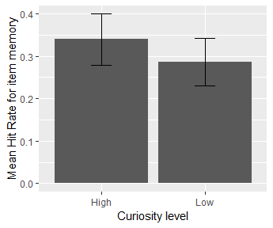

```
    Paired t-test

data:  SeenHit by RatingGroup
t = 2.0799, df = 39, p-value = 0.04415
alternative hypothesis: true difference in means is not equal to 0
95 percent confidence interval:
 0.001471108 0.105473336
sample estimates:
mean of the differences
             0.05347222
```

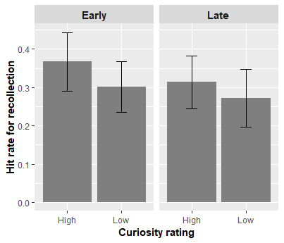

#### 4.2.3.2 Stats on it

```
Linear mixed-effects model fit by maximum likelihood
 Data: Curiosity.Recall.Old.Collapsed.Alt[!SubjectNo %in% bad.ps.less.strict]
```

|  | AIC | BIC | logLik |
| --- | --- | --- | --- |
|  | -63.20721 | -38.60582 | 39.60361 |

```
Random effects:
 Formula: ~1 | SubjectNo
        (Intercept)
StdDev:   0.1573655

 Formula: ~1 | RatingGroup %in% SubjectNo
        (Intercept)
StdDev:  0.04077879

 Formula: ~1 | ItemOrderType %in% RatingGroup %in% SubjectNo
        (Intercept)   Residual
StdDev:   0.1428369 0.04527919

Fixed effects: SeenHit ~ RatingGroup * ItemOrderType
```

|  | Value | Std.Error | DF | t-value | p-value |
| --- | --- | --- | --- | --- | --- |
| (Intercept) | 0.3670833 | 0.03540223 | 78 | 10.368934 | 0.0000 |
| RatingGroupLow | -0.0656944 | 0.03516663 | 39 | -1.868090 | 0.0693 |
| ItemOrderTypeLate | -0.0536111 | 0.03393250 | 78 | -1.579934 | 0.1182 |
| RatingGroupLow:ItemOrderTypeLate | 0.0244444 | 0.04798780 | 78 | 0.509389 | 0.6119 |

```
 Correlation:
                                 (Intr) RtngGL ItmOTL
RatingGroupLow                   -0.497
ItemOrderTypeLate                -0.479  0.482
RatingGroupLow:ItemOrderTypeLate  0.339 -0.682 -0.707

Standardized Within-Group Residuals:
         Min           Q1          Med           Q3          Max
-0.703230669 -0.184874046  0.006192257  0.180646750  0.622106187

Number of Observations: 160
Number of Groups:
                                    SubjectNo                    RatingGroup %in% SubjectNo
                                           40                                            80
ItemOrderType %in% RatingGroup %in% SubjectNo
                                          160
```

# 5 Curiosity and novelty

## 5.1 Testing the effects of curiosity rating and novelty together

Build models with item memory accuracy as $y$ and examine effects of curiosity rating and novelty together by including them into the model separately and then comparing the model fits.

|  | Model | df | AIC | BIC | logLik | Test | L.Ratio | p-value |
| --- | --- | --- | --- | --- | --- | --- | --- | --- |
| baseline.rating | 1 | 4 | -56.47495 | -42.61962 | 32.23747 |  |  |  |
| rating.intercept | 2 | 5 | -60.31095 | -42.99179 | 35.15547 | 1 vs 2 | 5.835998 | 0.0157 |
| rating.slope | 3 | 9 | -56.56845 | -25.39396 | 37.28422 | 2 vs 3 | 4.257502 | 0.3723 |
| novelty.model.1 | 4 | 10 | -54.60237 | -19.96405 | 37.30118 | 3 vs 4 | 0.033921 | 0.8539 |
| interaction.model | 5 | 11 | -53.38208 | -15.27993 | 37.69104 | 4 vs 5 | 0.779715 | 0.3772 |

### 5.1.1 Check the complete model

```
Linear mixed-effects model fit by maximum likelihood
 Data: OutsideObjectsMemory[!SubjectNo %in% bad.ps.less.strict]
```

|  | AIC | BIC | logLik |
| --- | --- | --- | --- |
|  | -53.38208 | -15.27993 | 37.69104 |

```
Random effects:
 Formula: ~1 + CuriosityRating | SubjectNo
 Structure: General positive-definite, Log-Cholesky parametrization
                StdDev     Corr
(Intercept)     0.19868842 (Intr)
CuriosityRating 0.03246124 -0.629

 Formula: ~1 + CuriosityRating | Group %in% SubjectNo
 Structure: General positive-definite, Log-Cholesky parametrization
                StdDev       Corr
(Intercept)     0.0026047541 (Intr)
CuriosityRating 0.0001188406 -0.009
Residual        0.1697943612

Fixed effects: SeenHit ~ CuriosityRating + Group + CuriosityRating:Group
```

|  | Value | Std.Error | DF | t-value | p-value |
| --- | --- | --- | --- | --- | --- |
| (Intercept) | 0.20969791 | 0.05329599 | 154 | 3.934591 | 0.0001 |
| CuriosityRating | 0.02532564 | 0.01404850 | 154 | 1.802729 | 0.0734 |
| GroupNovel | 0.09041915 | 0.11479717 | 39 | 0.787643 | 0.4357 |
| CuriosityRating:GroupNovel | -0.01966138 | 0.02194831 | 154 | -0.895804 | 0.3718 |

```
 Correlation:
                           (Intr) CrstyR GrpNvl
CuriosityRating            -0.828
GroupNovel                 -0.280  0.286
CuriosityRating:GroupNovel  0.425 -0.524 -0.942

Standardized Within-Group Residuals:
       Min         Q1        Med         Q3        Max
-2.1268677 -0.5902655 -0.0577787  0.5658924  2.5957289

Number of Observations: 236
Number of Groups:
           SubjectNo Group %in% SubjectNo
                  40                   80
```

## 5.2 What about the other way around

|  | Model | df | AIC | BIC | logLik | Test | L.Ratio | p-value |
| --- | --- | --- | --- | --- | --- | --- | --- | --- |
| baseline.rating | 1 | 4 | -56.47495 | -42.61962 | 32.23747 |  |  |  |
| novelty.model.1 | 2 | 5 | -57.43929 | -40.12013 | 33.71964 | 1 vs 2 | 2.964340 | 0.0851 |
| rating.model.1 | 3 | 6 | -58.39208 | -37.60909 | 35.19604 | 2 vs 3 | 2.952790 | 0.0857 |
| rating.model.2 | 4 | 10 | -54.60237 | -19.96405 | 37.30118 | 3 vs 4 | 4.210292 | 0.3783 |
| interaction.model | 5 | 11 | -53.38208 | -15.27993 | 37.69104 | 4 vs 5 | 0.779715 | 0.3772 |

### 5.2.1 Check the complete model

```
Linear mixed-effects model fit by maximum likelihood
 Data: OutsideObjectsMemory[!SubjectNo %in% bad.ps.less.strict]
```

|  | AIC | BIC | logLik |
| --- | --- | --- | --- |
|  | -53.38208 | -15.27993 | 37.69104 |

```
Random effects:
 Formula: ~1 + CuriosityRating | SubjectNo
 Structure: General positive-definite, Log-Cholesky parametrization
                StdDev     Corr
(Intercept)     0.19868842 (Intr)
CuriosityRating 0.03246124 -0.629

 Formula: ~1 + CuriosityRating | Group %in% SubjectNo
 Structure: General positive-definite, Log-Cholesky parametrization
                StdDev       Corr
(Intercept)     0.0026047539 (Intr)
CuriosityRating 0.0001188406 -0.009
Residual        0.1697943612

Fixed effects: SeenHit ~ Group + CuriosityRating + Group:CuriosityRating
```

|  | Value | Std.Error | DF | t-value | p-value |
| --- | --- | --- | --- | --- | --- |
| (Intercept) | 0.20969791 | 0.05329599 | 154 | 3.934591 | 0.0001 |
| GroupNovel | 0.09041915 | 0.11479717 | 39 | 0.787643 | 0.4357 |
| CuriosityRating | 0.02532564 | 0.01404850 | 154 | 1.802729 | 0.0734 |
| GroupNovel:CuriosityRating | -0.01966138 | 0.02194831 | 154 | -0.895804 | 0.3718 |

```
 Correlation:
                           (Intr) GrpNvl CrstyR
GroupNovel                 -0.280
CuriosityRating            -0.828  0.286
GroupNovel:CuriosityRating  0.425 -0.942 -0.524

Standardized Within-Group Residuals:
       Min         Q1        Med         Q3        Max
-2.1268677 -0.5902655 -0.0577787  0.5658924  2.5957289

Number of Observations: 236
Number of Groups:
           SubjectNo Group %in% SubjectNo
                  40                   80
```

## 5.3 Check the collapsed data

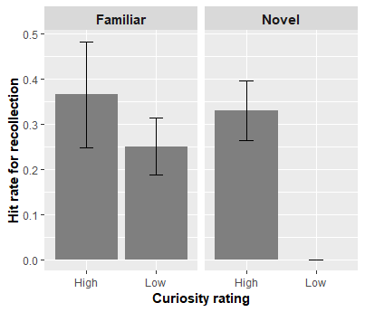

#### 5.3.0.1 Stats on it

```
Linear mixed-effects model fit by maximum likelihood
 Data: Curiosity.Recall.Old.Collapsed.Interaction[!SubjectNo %in% bad.ps.less.strict]
```

|  | AIC | BIC | logLik |
| --- | --- | --- | --- |
|  | -45.32232 | -25.23544 | 30.66116 |

```
Random effects:
 Formula: ~1 | SubjectNo
        (Intercept)
StdDev:   0.1287183

 Formula: ~1 | CuriosityRatingType %in% SubjectNo
        (Intercept)
StdDev:   0.1024441

 Formula: ~1 | Group %in% CuriosityRatingType %in% SubjectNo
        (Intercept)   Residual
StdDev:  0.09092163 0.04220837

Fixed effects: SeenHit ~ CuriosityRatingType * Group
```

|  | Value | Std.Error | DF | t-value | p-value |
| --- | --- | --- | --- | --- | --- |
| (Intercept) | 0.3255099 | 0.04341829 | 39 | 7.497067 | 0.0000 |
| CuriosityRatingTypeLow | -0.0664458 | 0.04610082 | 35 | -1.441316 | 0.1584 |
| GroupNovel | 0.0043512 | 0.03795021 | 13 | 0.114656 | 0.9105 |
| CuriosityRatingTypeLow:GroupNovel | -0.2221456 | 0.10149745 | 13 | -2.188682 | 0.0475 |

```
 Correlation:
                                  (Intr) CrsRTL GrpNvl
CuriosityRatingTypeLow            -0.738
GroupNovel                        -0.715  0.688
CuriosityRatingTypeLow:GroupNovel  0.274 -0.326 -0.382

Standardized Within-Group Residuals:
         Min           Q1          Med           Q3          Max
-0.621528465 -0.220815430 -0.005424137  0.192421464  0.631334788

Number of Observations: 91
Number of Groups:
                                    SubjectNo            CuriosityRatingType %in% SubjectNo
                                           40                                            76
Group %in% CuriosityRatingType %in% SubjectNo
                                           91
```

### 5.3.1 Alternative way to collapse data

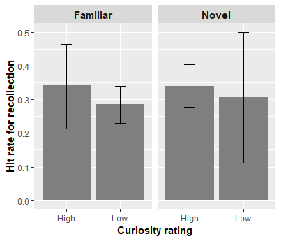

```
Linear mixed-effects model fit by maximum likelihood
 Data: Curiosity.Recall.Old.Collapsed.Alt.Interaction[!SubjectNo %in%      bad.ps.less.strict]
```

|  | AIC | BIC | logLik |
| --- | --- | --- | --- |
|  | -50.23194 | -29.80093 | 33.11597 |

```
Random effects:
 Formula: ~1 | SubjectNo
        (Intercept)
StdDev:   0.1543493

 Formula: ~1 | RatingGroup %in% SubjectNo
        (Intercept)
StdDev:  0.06388824

 Formula: ~1 | Group %in% RatingGroup %in% SubjectNo
        (Intercept)   Residual
StdDev:   0.1018092 0.03935519

Fixed effects: SeenHit ~ RatingGroup * Group
```

|  | Value | Std.Error | DF | t-value | p-value |
| --- | --- | --- | --- | --- | --- |
| (Intercept) | 0.3533732 | 0.05178970 | 39 | 6.823234 | 0.0000 |
| RatingGroupLow | -0.0686510 | 0.04977820 | 39 | -1.379138 | 0.1757 |
| GroupNovel | -0.0144843 | 0.04759005 | 13 | -0.304356 | 0.7657 |
| RatingGroupLow:GroupNovel | 0.0542271 | 0.07843336 | 13 | 0.691378 | 0.5015 |

```
 Correlation:
                          (Intr) RtngGL GrpNvl
RatingGroupLow            -0.799
GroupNovel                -0.793  0.825
RatingGroupLow:GroupNovel  0.555 -0.657 -0.687

Standardized Within-Group Residuals:
         Min           Q1          Med           Q3          Max
-0.660788341 -0.181005658  0.008927672  0.184353321  0.584299080

Number of Observations: 95
Number of Groups:
                            SubjectNo            RatingGroup %in% SubjectNo
                                   40                                    80
Group %in% RatingGroup %in% SubjectNo
                                   95
```

# 6 Curiosity effects in the *Novel* group

## 6.1 Mean accuracy of item memory as a function of curiosity rating